# Utilizar tu proyecto como un módulo de Python

## Descargamos el notebook:

https://static.platzi.com/media/public/uploads/1-0-jvelezmagic-full_b038c258-f03a-4940-b4ee-6945ee152ee6.ipynb.

Lo copiamos en la carpeta de notebooks. Lo abrimos en VSCode y nos fijamos que el kernel sea el que creamos anteriormente `final_project`. Como se puede observar tenemos una serie de código y funciones que realizan determinada labor.

Todos estos datos son de COVID, casos confirmados y algunos otras observaciones.

Entender que hace y como está estructurado no corresponde al curso, solo es un ejemplo de notebook.

Pero podemos tomar el [Curso para Crear tus Proyectos de Ciencia de Datos](https://platzi.com/cursos/proyectos-data-science/).

Veamos que la linea

```
import final_project.utils.paths as path
```

Usa el proyecto como una librería y que si vamos a la carpeta y accedemos al archivo paths.py obtenemos la función que usamos en clases anteriores para crear `shortcuts` con las rutas, en esencia la función se convirtió en un script y la podemos usar dentro del notebook.

Al ejecutar la celda me marca un error debido a que estoy fuera de la carpeta del proyecto. Para poder correr bien mi archivo lo replicaré dentro de la carpeta del proyecto.

COVID.ipynb

Procedamos a correrlo. Me sigue marcando error.  
Vamos instalar el proyecto como librería

## Instalar proyecto como librería

Antes de esto, vayamos desde la terminal al archivo que duplique y abramos VSCode, para realizar lo siguiente:

Para hacer esto presionamos `ctrl+shift+p`. Damos Create New terminal Integrated. Activamos el entorno de conda `conda activate final_project`.

[figure not shown]

Una vez estando dentro del ambiente procedemos a instalar el proyecto, a traves de la terminal integrada colocamos:

```
pip install --editable .
```

¿Qué significa esto? Significa que tu puedes comenzar a editar tu proyecto, modificar las funnies, modificar el comportamiento de algunas variables y se verá reflejado en lo que escribamos dentro.

Para ello existe la extensión `autoreload` y significa que cuando tu cambies algún contenido en la función se va a actualizar automáticamente sin necesidad de realizar nuevamente el `import`.

Una vez que hemos ejecutado la linea anterior, recarguemos el kernel.

Listo!!

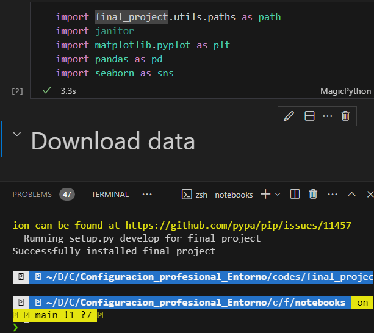

Modifiquemos el archivo `paths.py` con una nueva función, y ejecutemos una nueva celda de código sin ejecutar nuevamente los `imports`.

**Modificación del archivo**

```
def hello():
        print('hello')
```

Ejecución de una nueva celda:

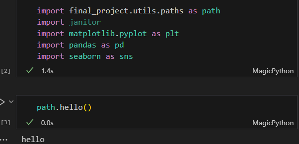

Modificando de nuevo

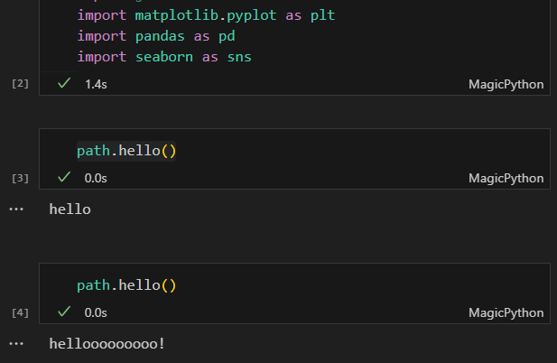

Como se puede observar no se necesita recargar o importar de nuevo la librería. Automáticamente se actualiza la función de nuestro proyecto.

Así de esta manera podemos trabajar en conjunto con los **Jupyter Notebooks** y **Scripts de python** abstrayendo las funciones que necesitamos en un solo archivo de Python, para manipular otras cosas.

Asegurémonos de ejecutar todo el notebook y que tenemos todas las variables necesarias para trabajar.

Lo importante de los **Notebook** es que sirven para el prototipado y la exploración.

Digamos que la parte de la gráfica queremos convertirla en la función final. Desarrollemos la función:

```
#definiendo la función en bloque de código

def covid_time_series():
    sns.lineplot(
        data=some_latam_countries_df,
        x="date",
        y="value",
        hue="country_region"
    )

    plt.xticks(rotation=15)
    plt.xlabel("Date")
    plt.ylabel("Value")
    plt.title("Latam covid time series");

#probando la función en otro bloque de código
covid_time_series()
```

Generalizando para un Data Frame más amplio:

```
#definiendo la función en bloque de código

def covid_time_series(df):
    sns.lineplot(
        data=df,
        x="date",
        y="value",
        hue="country_region"
    )

    plt.xticks(rotation=15)
    plt.xlabel("Date")
    plt.ylabel("Value")
    plt.title("Latam covid time series");

#probando la función en otro bloque de código
covid_time_series(some_latam_countries_df)
```

Una vez que hemos construido la función copiamos el código y lo pegamos dentro de visualize.py.

Así quedará de forma final

```
import matplotlib.pyplot as plt
import pandas as pd
import seaborn as sns

#definiendo la función en bloque de código

def covid_time_series(df:pd.DataFrame):
    sns.lineplot(
        data=df,
        x="date",
        y="value",
        hue="country_region"
    )

    plt.xticks(rotation=15)
    plt.xlabel("Date")
    plt.ylabel("Value")
    plt.title("Latam covid time series");
```

Lo ponemos a prueba en el notebook:

```
#importando la función
import final_project.visualization.visualize as visualize
#probando la función en otro bloque de código
visualize.covid_time_series(some_latam_countries_df)
```

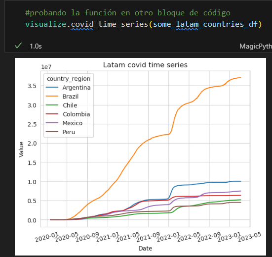

Ha funcionado y con esto ya hemos logrado abstraer la lógica de un bloque de código dentro de una función que hemos logrado reutilizar multiples veces.

Recordemos que también si queremos modificar las funciones, no tenemos que volver a importarlas gracias al uso de `editable` y los bloques de código del inicio:

```
%load_ext autoreload
%autoreload 2
```

Ahora hay que abstraer el bloque de código siguiente que nos encontramos al final del archivo, para convertirlo en una función. Y utilizar la función como si fuera un módulo de Python.

### Función

```
#Definiendo la función dentro del mismo archivo
def latam_grafic(df: pd.DataFrame):
    sns.barplot(
        data=df,
        x="value",
        y="country_region",
        hue="country_region"
    )

    plt.xlabel("Value")
    plt.ylabel("Country Region")
    plt.title("Latam countries in a global context");
#llamandola en otro bloque de código
visualize.latam_grafic(top_countries_df)
```

**Resultado**

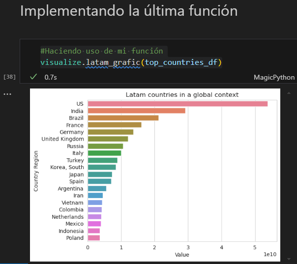

## 1.0 Full Exploratory Data Analysis

Una vez descargado, puedes instalar un proyecto como módulo de Python usando el siguiente comando en la terminal:

`pip install --editable`

Para que se reinicie el kernel, cada vez que reimportes los módulos después de hacer un cambio en estos, agrega esto en la primera celda:

```
%load_ext autoreload
%autoreload 2
```

El hacer el autoreload te ayuda a externalizar trozos de código en archivos .py, como la creación de gráficos.  
Los notebooks son buenos para hacer exploración, pero no para producción.